# PEC1-final-v1

[figure not shown]

M2.855 · Modelos avanzados de minería de datos · PEC1

2018-2 · Máster universitario en Ciencia de datos (Data science)

Estudios de Informática, Multimedia y Telecomunicación

**Autor: Joaquín Fernández León**

# PEC 1: Preparación de datos

A lo largo de esta práctica veremos como aplicar distintas técnicas para la carga y preparación de datos:

1. Carga de conjuntos de datos
2. Análisis de los datos  
   2.1 Análisis estadístico básico  
   2.2 Análisis exploratorio de los datos
3. Reducción de dimensionalidad
4. Aplicación de CART

Para ello vamos a necesitar las siguientes librerías:

```python
from sklearn import datasets
from sklearn.decomposition import PCA
from sklearn.manifold import TSNE
from sklearn.model_selection import train_test_split
from sklearn import tree
from sklearn.tree import DecisionTreeClassifier
from sklearn.metrics import accuracy_score, confusion_matrix
import numpy as np
import matplotlib.pyplot as plt
%matplotlib inline
import pandas as pd
pd.set_option('display.max_columns', None)
```

# 1. Carga del conjunto de datos (1 punto)

En primer lugar, deberéis cargar el conjunto de datos Breast Cancer Wisconsin (más información en https://archive.ics.uci.edu/ml/datasets/Breast+Cancer+Wisconsin+(Diagnostic)). Éste se puede descargar de Internet o puede ser cargado directamente de la librería "scikit-learn", que incorpora un conjunto de datasets muy conocidos y empleados para minería de datos y machine learning (http://scikit-learn.org/stable/datasets/index.html).

**Implementación:** Cargad el conjunto de datos "Breast Cancer Wisconsin" y mostrad el número y nombre de los atributos (variables que podrían ser usadas para predecir la respuesta "Diagnosis"), así como el número de filas obtenidas.

Hemos descargado el dataset desde la web de Kaggle: https://www.kaggle.com/uciml/breast-cancer-wisconsin-data

Sugerencia: si usáis sklearn (sklearn.datasets.load_breast_cancer), explorad las diferentes keys del objeto obtenido.

```python
data = pd.read_csv('input/data.csv')

print("Analizamos el tipo de dato para cada variable:")
print(data.dtypes)

print("El tamaño del csv es:")
n_samples, n_features = data.shape
print("Numero de filas: ", n_samples, "y el numero de columnas", n_features)
```

```
Analizamos el tipo de dato para cada variable:
id                           int64
diagnosis                   object
radius_mean                float64
texture_mean               float64
perimeter_mean             float64
area_mean                  float64
smoothness_mean            float64
compactness_mean           float64
concavity_mean             float64
concave points_mean        float64
symmetry_mean              float64
fractal_dimension_mean     float64
radius_se                  float64
texture_se                 float64
perimeter_se               float64
area_se                    float64
smoothness_se              float64
compactness_se             float64
concavity_se               float64
concave points_se          float64
symmetry_se                float64
fractal_dimension_se       float64
radius_worst               float64
texture_worst              float64
perimeter_worst            float64
area_worst                 float64
smoothness_worst           float64
compactness_worst          float64
concavity_worst            float64
concave points_worst       float64
symmetry_worst             float64
fractal_dimension_worst    float64
Unnamed: 32                float64
dtype: object
El tamaño del csv es:
Numero de filas:  569 y el numero de columnas 33
```

```python
# Eliminamos la columna id y otra que es basura (unnamed)
data_diagnosis = data.diagnosis
delete = ['Unnamed: 32','id']

# Guardamos nuestra variable data_train que utilizaremos en el ejercicio 4 para entrenar
data_train = data.drop(delete,axis = 1)

# Creamos otra variable all_data donde guardaremos todo y además un mapeo de la variable categórica M y B por 0 y 1
all_data = data.drop(delete,axis = 1)

all_data['binary'] = all_data['diagnosis'].map({'M': 0, 'B': 1})

# Guardamos el subconjunto de datos de tumores malignos y benignos
malignant=all_data[all_data['binary']==0] # define malignant
benign=all_data[all_data['binary']==1] # define benign

# Creamos las variables x para todos los atributos e y para la etiqueta de clase
y = data.diagnosis
x = data.drop(['Unnamed: 32','id', 'diagnosis'],axis = 1 )

# Mostramos la variable x
x.head()
```

|  | radius_mean | texture_mean | perimeter_mean | area_mean | smoothness_mean | compactness_mean | concavity_mean | concave points_mean | symmetry_mean | fractal_dimension_mean | radius_se | texture_se | perimeter_se | area_se | smoothness_se | compactness_se | concavity_se | concave points_se | symmetry_se | fractal_dimension_se | radius_worst | texture_worst | perimeter_worst | area_worst | smoothness_worst | compactness_worst | concavity_worst | concave points_worst | symmetry_worst | … |
| --- | --- | --- | --- | --- | --- | --- | --- | --- | --- | --- | --- | --- | --- | --- | --- | --- | --- | --- | --- | --- | --- | --- | --- | --- | --- | --- | --- | --- | --- | --- |
| 0 | 17.99 | 10.38 | 122.80 | 1001.0 | 0.11840 | 0.27760 | 0.3001 | 0.14710 | 0.2419 | 0.07871 | 1.0950 | 0.9053 | 8.589 | 153.40 | 0.006399 | 0.04904 | 0.05373 | 0.01587 | 0.03003 | 0.006193 | 25.38 | 17.33 | 184.60 | 2019.0 | 0.1622 | 0.6656 | 0.7119 | 0.2654 | 0.4601 | … |
| 1 | 20.57 | 17.77 | 132.90 | 1326.0 | 0.08474 | 0.07864 | 0.0869 | 0.07017 | 0.1812 | 0.05667 | 0.5435 | 0.7339 | 3.398 | 74.08 | 0.005225 | 0.01308 | 0.01860 | 0.01340 | 0.01389 | 0.003532 | 24.99 | 23.41 | 158.80 | 1956.0 | 0.1238 | 0.1866 | 0.2416 | 0.1860 | 0.2750 | … |
| 2 | 19.69 | 21.25 | 130.00 | 1203.0 | 0.10960 | 0.15990 | 0.1974 | 0.12790 | 0.2069 | 0.05999 | 0.7456 | 0.7869 | 4.585 | 94.03 | 0.006150 | 0.04006 | 0.03832 | 0.02058 | 0.02250 | 0.004571 | 23.57 | 25.53 | 152.50 | 1709.0 | 0.1444 | 0.4245 | 0.4504 | 0.2430 | 0.3613 | … |
| 3 | 11.42 | 20.38 | 77.58 | 386.1 | 0.14250 | 0.28390 | 0.2414 | 0.10520 | 0.2597 | 0.09744 | 0.4956 | 1.1560 | 3.445 | 27.23 | 0.009110 | 0.07458 | 0.05661 | 0.01867 | 0.05963 | 0.009208 | 14.91 | 26.50 | 98.87 | 567.7 | 0.2098 | 0.8663 | 0.6869 | 0.2575 | 0.6638 | … |
| 4 | 20.29 | 14.34 | 135.10 | 1297.0 | 0.10030 | 0.13280 | 0.1980 | 0.10430 | 0.1809 | 0.05883 | 0.7572 | 0.7813 | 5.438 | 94.44 | 0.011490 | 0.02461 | 0.05688 | 0.01885 | 0.01756 | 0.005115 | 22.54 | 16.67 | 152.20 | 1575.0 | 0.1374 | 0.2050 | 0.4000 | 0.1625 | 0.2364 | … |

# 2. Análisis de los datos

## 2.1 Análisis estadístico básico (1 punto)

**Implementación:** Realizad un análisis estadístico básico indicando, para cada atributo numérico del conjunto de datos, su valor medio y desviación estándard. Para las variables categóricas (en los atributos o la respuesta, si las hay), mostrad la frecuencia con la que aparecen las diferentes clases.

Sugerencia: podeis usar la librería 'pandas' y sus funciones 'describe' y 'value_counts'

```python
data_train.describe()
```

|  | radius_mean | texture_mean | perimeter_mean | area_mean | smoothness_mean | compactness_mean | concavity_mean | concave points_mean | symmetry_mean | fractal_dimension_mean | radius_se | texture_se | perimeter_se | area_se | smoothness_se | compactness_se | concavity_se | concave points_se | symmetry_se | fractal_dimension_se | radius_worst | texture_worst | perimeter_worst | area_worst | smoothness_worst | compactness_worst | concavity_worst | concave points_worst | symmetry_worst | … |
| --- | --- | --- | --- | --- | --- | --- | --- | --- | --- | --- | --- | --- | --- | --- | --- | --- | --- | --- | --- | --- | --- | --- | --- | --- | --- | --- | --- | --- | --- | --- |
| count | 569.000000 | 569.000000 | 569.000000 | 569.000000 | 569.000000 | 569.000000 | 569.000000 | 569.000000 | 569.000000 | 569.000000 | 569.000000 | 569.000000 | 569.000000 | 569.000000 | 569.000000 | 569.000000 | 569.000000 | 569.000000 | 569.000000 | 569.000000 | 569.000000 | 569.000000 | 569.000000 | 569.000000 | 569.000000 | 569.000000 | 569.000000 | 569.000000 | 569.000000 | … |
| mean | 14.127292 | 19.289649 | 91.969033 | 654.889104 | 0.096360 | 0.104341 | 0.088799 | 0.048919 | 0.181162 | 0.062798 | 0.405172 | 1.216853 | 2.866059 | 40.337079 | 0.007041 | 0.025478 | 0.031894 | 0.011796 | 0.020542 | 0.003795 | 16.269190 | 25.677223 | 107.261213 | 880.583128 | 0.132369 | 0.254265 | 0.272188 | 0.114606 | 0.290076 | … |
| std | 3.524049 | 4.301036 | 24.298981 | 351.914129 | 0.014064 | 0.052813 | 0.079720 | 0.038803 | 0.027414 | 0.007060 | 0.277313 | 0.551648 | 2.021855 | 45.491006 | 0.003003 | 0.017908 | 0.030186 | 0.006170 | 0.008266 | 0.002646 | 4.833242 | 6.146258 | 33.602542 | 569.356993 | 0.022832 | 0.157336 | 0.208624 | 0.065732 | 0.061867 | … |
| min | 6.981000 | 9.710000 | 43.790000 | 143.500000 | 0.052630 | 0.019380 | 0.000000 | 0.000000 | 0.106000 | 0.049960 | 0.111500 | 0.360200 | 0.757000 | 6.802000 | 0.001713 | 0.002252 | 0.000000 | 0.000000 | 0.007882 | 0.000895 | 7.930000 | 12.020000 | 50.410000 | 185.200000 | 0.071170 | 0.027290 | 0.000000 | 0.000000 | 0.156500 | … |
| 25% | 11.700000 | 16.170000 | 75.170000 | 420.300000 | 0.086370 | 0.064920 | 0.029560 | 0.020310 | 0.161900 | 0.057700 | 0.232400 | 0.833900 | 1.606000 | 17.850000 | 0.005169 | 0.013080 | 0.015090 | 0.007638 | 0.015160 | 0.002248 | 13.010000 | 21.080000 | 84.110000 | 515.300000 | 0.116600 | 0.147200 | 0.114500 | 0.064930 | 0.250400 | … |
| 50% | 13.370000 | 18.840000 | 86.240000 | 551.100000 | 0.095870 | 0.092630 | 0.061540 | 0.033500 | 0.179200 | 0.061540 | 0.324200 | 1.108000 | 2.287000 | 24.530000 | 0.006380 | 0.020450 | 0.025890 | 0.010930 | 0.018730 | 0.003187 | 14.970000 | 25.410000 | 97.660000 | 686.500000 | 0.131300 | 0.211900 | 0.226700 | 0.099930 | 0.282200 | … |
| 75% | 15.780000 | 21.800000 | 104.100000 | 782.700000 | 0.105300 | 0.130400 | 0.130700 | 0.074000 | 0.195700 | 0.066120 | 0.478900 | 1.474000 | 3.357000 | 45.190000 | 0.008146 | 0.032450 | 0.042050 | 0.014710 | 0.023480 | 0.004558 | 18.790000 | 29.720000 | 125.400000 | 1084.000000 | 0.146000 | 0.339100 | 0.382900 | 0.161400 | 0.317900 | … |
| max | 28.110000 | 39.280000 | 188.500000 | 2501.000000 | 0.163400 | 0.345400 | 0.426800 | 0.201200 | 0.304000 | 0.097440 | 2.873000 | 4.885000 | 21.980000 | 542.200000 | 0.031130 | 0.135400 | 0.396000 | 0.052790 | 0.078950 | 0.029840 | 36.040000 | 49.540000 | 251.200000 | 4254.000000 | 0.222600 | 1.058000 | 1.252000 | 0.291000 | 0.663800 | … |

```python
data_train['diagnosis'].describe()
```

```
count     569
unique      2
top         B
freq      357
Name: diagnosis, dtype: object
```

**Análisis:**

Aquí podemos observar para cada una de sus **30 variables** totales,su valor medio y desviación estándard.

Por lo general si comparamos a simple vista, los valores de media y mediana de los diferentes atributos se observa que toman un rango de valores bastante heterogéneo por lo que puede ser interesante aplicar una **normalización** para poder realizar mejores comparaciones

Por último, en la **variable de clase (el atributo diagnosis)** se puede ver que existe un ligero **desbalanceo**, lo que implica que haya más atributos de la clase de **tumores benignos** que de la de **tumores malignos.**

```
Number of Benign:  357
Number of Malignant :  212
```

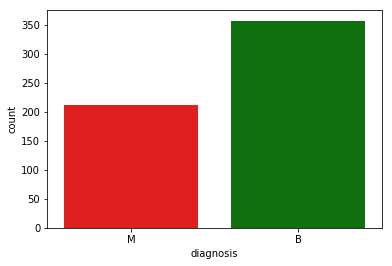

```python
import seaborn as sns
my_pal = {"M": "r", "B": "g"}
ax = sns.countplot(y,label="Count", palette=my_pal)
B, M = y.value_counts()
print('Number of Benign: ',B)
print('Number of Malignant : ',M)
```

## 2.2 Análisis exploratorio de los datos (3 puntos)

En este ejercicio vamos a explorar la relación de algunos de los atributos numéricos con la variable respuesta ("Diagnosis"), tanto gráficamente como cuantitativamente. Para empezar, seleccionad los 4 atributos que queréis explorar. Si habéis usado los nombres de columnas proporcionados por sklearn, una lista de posibles nombres de atributos serían:

```python
feats_to_explore = ['mean radius', 'mean texture', 'mean smoothness', 'mean symmetry']
```

**Implementación:** Utilizando una librería gráfica, como por ejemplo "matplotlib", realizad un gráfico del histograma de valores para cada uno de los atributos seleccionados, separados por los valores de clase de la respuesta ("Diagnosis"). La finalidad es observar como se distribuye cada uno de los atributos en función del valor de clase que toman, para poder identificar de forma visual y rápida si algunos atributos permiten diferenciar de forma clara los diferentes diagnósticos de los tumores.

```python
x_y = all_data.loc[:,['radius_mean', 'texture_mean', 'smoothness_mean', 'symmetry_mean', 'diagnosis']]
x_y.head()
```

|  | radius_mean | texture_mean | smoothness_mean | symmetry_mean | diagnosis |
| --- | --- | --- | --- | --- | --- |
| 0 | 17.99 | 10.38 | 0.11840 | 0.2419 | M |
| 1 | 20.57 | 17.77 | 0.08474 | 0.1812 | M |
| 2 | 19.69 | 21.25 | 0.10960 | 0.2069 | M |
| 3 | 11.42 | 20.38 | 0.14250 | 0.2597 | M |
| 4 | 20.29 | 14.34 | 0.10030 | 0.1809 | M |

A continuación mostraremos para cada **histograma** la distribución de los datos de los *tumores malignos* en rojo y los *tumores benignos* en verde para poder **comparar entre sí las posibles diferencias que pueden ayudar a detectar si un tumor es benigno o maligno**.

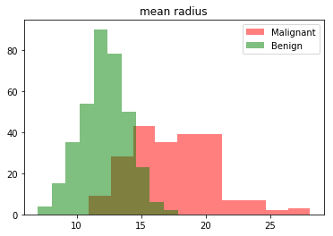

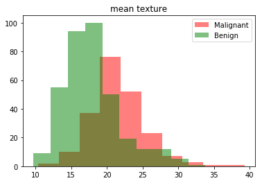

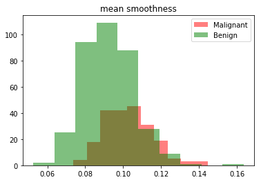

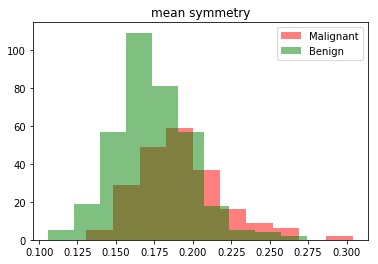

```python
lista = ['radius_mean', 'texture_mean', 'smoothness_mean', 'symmetry_mean', 'diagnosis']

malignant=x_y[x_y.diagnosis=='M'] # definimos los malignos
benign=x_y[x_y.diagnosis=='B'] # definimos los benignos
bins = 10

for i in range(0,4):
    plt.hist(malignant.loc[:,lista[i]], bins, alpha=0.5, color='r', label='Malignant')
    plt.hist(benign.loc[:,lista[i]], bins, alpha=0.5, color='g', label='Benign')
    plt.title(feats_to_explore[i])
    plt.legend(loc='upper right')
    plt.show()
```

**Análisis:**

Después de representar las variables de *'radius_mean', 'texture_mean', 'smoothness_mean' y 'symmetry_mean'* en diferentes histogramas, podemos afirmar que **los picos de los histogramas siempre obtienen un valor más alto para los tumores malignos que para los benignos**. Por tanto podemos decir que para estos datos, **los tumores malignos tienen mayor radio medio, mayor textura media, mayor suavidad media y mayor simetría media**.

**Diagramas de violín:**

Los diagramas de violín nos pueden ser útiles para visualizar la distribución de los datos tal y como hemos generado en la tabla del ejercicio 2.1.

Aquí también se puede observar que los valores de la mediana siempre son superiores en los tumores malignos que en los tumores benignos.

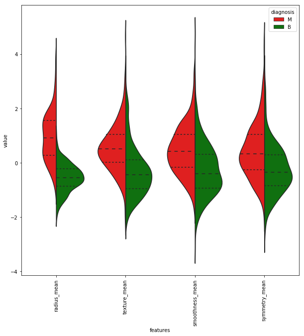

```python
def pintaDiagramaViolin(data, data_dia):
    data_n_2 = (data - data.mean()) / (data.std())              # estandarización
    data = pd.concat([y,data_n_2.iloc[:,[0,1,4,8]]],axis=1)
    data = pd.melt(data,id_vars="diagnosis",
                        var_name="features",
                        value_name='value')
    plt.figure(figsize=(10,10))
    my_pal = {"M": "r", "B": "g"}
    sns.violinplot(x="features", y="value", hue="diagnosis", data=data,split=True, inner="quart", palette=my_pal)
    plt.xticks(rotation=90)

pintaDiagramaViolin(x,y)
```

**Implementación:** Para cada uno de los atributos representados en el ejercicio anterior, mostrad la media y la desviación estándard para cada valor de clase de la respuesta ("Diagnosis"). La finalidad es verificar numéricamente las diferencias identificadas anteriormente de forma visual.

```python
#Obtenemos conjunto de datos para tumores malignos

#El eje 'X' será los diferentes atributos mientras que el eje 'Y' serán los valores del propios de la media
# y la desviación típica

aux = all_data[all_data['diagnosis']=='M'].describe()
mean_all_data_m = aux.loc['mean',:]
std_all_data_m = aux.loc['std',:]
mean_all_data_m.head()
```

```
radius_mean         17.462830
texture_mean        21.604906
perimeter_mean     115.365377
area_mean          978.376415
smoothness_mean      0.102898
Name: mean, dtype: float64
```

```python
#Obtenemos conjunto de datos para tumores benignos

#El eje 'X' será los diferentes atributos mientras que el eje 'Y' serán los valores del propios de la media
# y la desviación típica

aux = all_data[all_data['diagnosis']=='B'].describe()
mean_all_data_b = aux.loc['mean',:]
std_all_data_b = aux.loc['std',:]
mean_all_data_b.head()
```

```
radius_mean         12.146524
texture_mean        17.914762
perimeter_mean      78.075406
area_mean          462.790196
smoothness_mean      0.092478
Name: mean, dtype: float64
```

**Diagramas de medias y desviaciones estándares:**

Una vez calculados los valores medios y desviaciones estándares para cada atributo procedemos a visualizar.

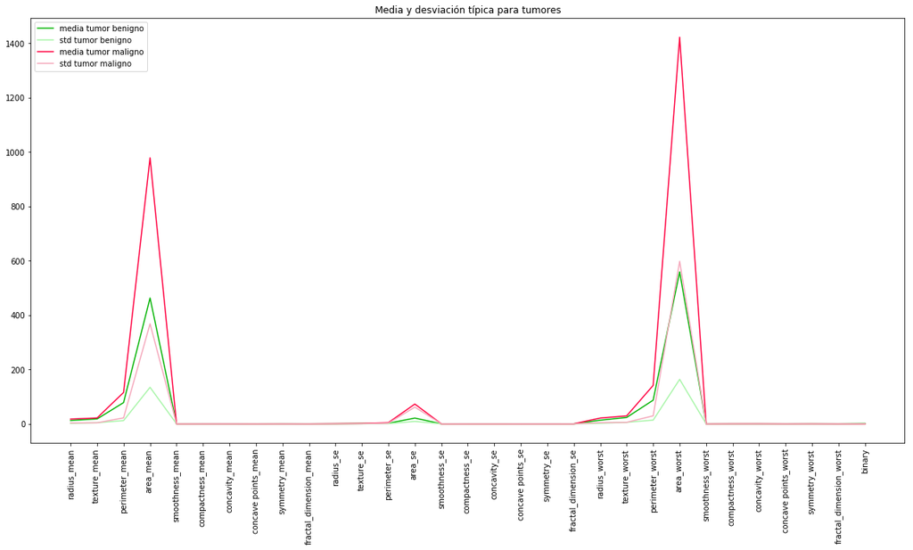

```python
# Dibujamos nuestro gráfico
plt.figure(figsize=(20,10))
plt.plot(mean_all_data_b, color="#04B404", label = "media tumor benigno")
plt.plot(std_all_data_b, color="#A9F5A9", label = "std tumor benigno")
plt.plot(mean_all_data_m, color="#FF0040", label = "media tumor maligno")
plt.plot(std_all_data_m, color="#F5A9BC", label = "std tumor maligno")
plt.title("Media y desviación típica para tumores")
plt.xticks(rotation=90)
plt.legend(loc="upper left")
plt.show()
```

**Análisis:**  
- Mirando los gráficos, qué atributos te parece que tienen valores claramente diferentes para diagnósticos benignos y malignos? Qué atributos no?

A simple vista vemos que **los valores de media, desviación de tumores malignos (líneas roja fuerte y roja clara) coinciden entre ellas para la mayoría de atributos y coinciden también con los valores de media y desviación para los tumores benignos (líneas verde fuerte y clara).**

Sin embargo, hay 6 atributos en los que no ocurre lo mismo. Estos atributos son: **'perimeter_mean', 'area_mean', 'area_se', 'radius_worst', 'perimeter_worst' y 'area_worst'**. En ellos **se aprecia una gran diferencia entre valores de la media para tumores benignos y malignos**.

- Mirando a los valores medios y desviaciones estándard calculadas, te parecen significativas las diferencias para diagnósticos benignos y malignos?

En estos atributos se observa que hay una gran diferencia (aproximadamente de casi el doble en comparación de uno con otro) en la desviación típica por lo que **podemos deducir que por lo general para los tumores malignos existe un rango de valores muchísmo más amplio y grande que para los tumores benignos**. Ocurre también una **gran diferencia en los valores de media de estos atributos** y se puede entender que **la tendencia central para los tumores malignos es por lo general muchísimo más alta en estos atributos en comparación a los tumores benignos**.

- BONUS: qué test estadístico podrías usar para comparar las distribuciones de los valores de los atributos cuando los diagnósticos son benignos o malignos? Úsalo para evaluar qué atributos (de entre todos los del conjunto de datos) tienen valores más parecidos en tumores benignos y malignos. Interpreta el resultado.

En este caso utilizaríamos un test estadístico entre dos muestras basado en la distribución normal. Por ello nuestra hiótesis nula sería que ambas distribuciones tienen valores parecidos (μ_1 == μ_2) en otro caso rechazaríamos la hipótesis nula y podríamos decir que no tienen valores parecidos en ambas muestras.

```python
from scipy import stats
stats.ttest_ind(malignant.drop(['diagnosis'], axis=1), benign.drop(['diagnosis'], axis=1))
```

```
Ttest_indResult(statistic=array([25.43582161, 10.86720108,  9.14609881,  8.33831179]), pvalue=array([8.46594057e-96, 4.05863605e-25, 1.05185036e-18, 5.73338403e-16]))
```

Para un 95% de confianza (nivel significativo de α=0.05) tenemos que el p-value para las variables de *'radius_mean', 'texture_mean', 'smoothness_mean' y 'symmetry_mean'* son inferiores a α y rechazamos la hipótisis nula.

# 3. Reducción de dimensionalidad (2 puntos)

En este ejercicio deberéis aplicar métodos de reducción de dimensionalidad al conjunto original de datos. El objetivo es reducir el conjunto de atributos a un nuevo conjunto con menos dimensiones.

**Implementación:** Aplicad los métodos de reducción de dimensionalidad:  
- Principal Component Analysis (PCA)  
- t-distributed Stochastic Neighbor Embedding (t-SNE)  
para reducir el conjunto de datos a 2 dimensiones.

Sugerencia: No es necesario que programéis los algoritmos, podéis hacer uso de las implementaciones disponibles en la librería "scikit-learn".

**Principal Component Analysis (PCA) :** Para aplicar correctamente esta técnica **debemos aplicar una normalización en los datos**. De esta manera utilizando la librería de **StandardScaler normalizaremos y a cada dato se le restará la media de la variable y se dividirá por la desviación típica**. De esta manera conseguiremos la normalización de media = 0 y desviación estandar = 1.

A continuación, hacemos uso de la función PCA de la librería scikit-learn y reducimos la dimensionalidad de nuestro dataset a **2 dimensiones**. Después lo guardamos en un dataframe que tendrá los dos atributos seleccionados por el PCA y le añadimos la etiqueta de clase diagnosis.

```python
# Principal Component Analysis (PCA)
from sklearn.preprocessing import StandardScaler
x_scaled = StandardScaler().fit_transform(x)

from sklearn.decomposition import PCA

pca = PCA(n_components=2)
principalComponents = pca.fit_transform(x_scaled)

principalDf = pd.DataFrame(data = principalComponents
             , columns = ['principal component 1', 'principal component 2'])

finalDf = pd.concat([principalDf, all_data[['diagnosis']]], axis = 1)
```

**t-distributed Stochastic Neighbor Embedding (t-SNE):** Para aplicar t-SNE debemos aplicar una normalización de datos al igual que hemos hecho sobre PCA y a continuación el algoritmo procederá a realizar una exploración de los datos y atributos con una técnica no lineal.

```python
# t-distributed Stochastic Neighbor Embedding (t-SNE)
from sklearn.manifold import TSNE

tsne = TSNE(n_components=2, verbose=1, perplexity=40, n_iter=300)

tsne_results = tsne.fit_transform(x_scaled)

df_tsne = pd.DataFrame(data = tsne_results,
                           columns = ['t-sne1', 't-sne2'])


df_tsne_with_target = pd.concat([df_tsne, all_data[['diagnosis']]], axis = 1)
```

```
[t-SNE] Computing 121 nearest neighbors...
[t-SNE] Indexed 569 samples in 0.001s...
[t-SNE] Computed neighbors for 569 samples in 0.039s...
[t-SNE] Computed conditional probabilities for sample 569 / 569
[t-SNE] Mean sigma: 1.522404
[t-SNE] KL divergence after 250 iterations with early exaggeration: 64.981239
[t-SNE] KL divergence after 300 iterations: 0.908597
```

**Implementación:** Generad un gráfico (en 2D) con el resultado de cada uno de los métodos de reducción de la dimensión, usando colores diferentes para cada clase de la respuesta, con el objetivo de visualizar si es posible separar eficientemente las clases empleando estos métodos.

**Principal Component Analysis (PCA) :** Visualizamos los datos en función de los dos atributos seleccionados por nuestro algoritmo.

Se puede observar una separación lineal clara entre las clases benigna y maligna. Esto indica que ambos atributos no son linealmente dependientes y que pueden ser muy útiles para entrenar y realizar predicciones para nuevos conjuntos de datos.

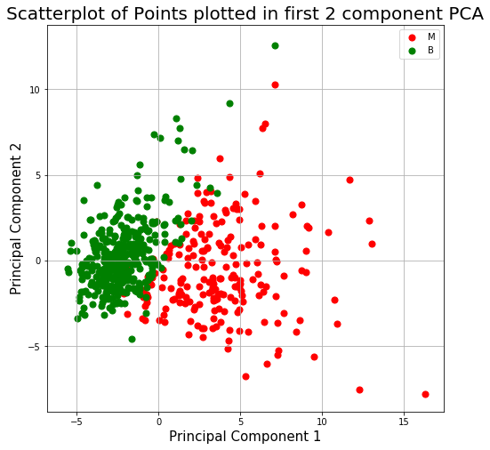

```python
#Visualización para el método PCA
fig = plt.figure(figsize = (8,8))
ax = fig.add_subplot(1,1,1)
ax.set_xlabel('Principal Component 1', fontsize = 15)
ax.set_ylabel('Principal Component 2', fontsize = 15)
ax.set_title('Scatterplot of Points plotted in first 2 component PCA', fontsize = 20)
targets = ['M', 'B']
colors = ['r', 'g']
for target, color in zip(targets,colors):
    indicesToKeep = finalDf['diagnosis'] == target
    ax.scatter(finalDf.loc[indicesToKeep, 'principal component 1']
               , finalDf.loc[indicesToKeep, 'principal component 2']
               , c = color
               , s = 50)
ax.legend(targets)
ax.grid()
```

**t-distributed Stochastic Neighbor Embedding (t-SNE):** Visualizamos los datos en función de los dos atributos seleccionados por nuestro algoritmo.

En este caso se puede ver tambiénuna separación lineal clara entre las clases benigna y maligna aunque esta vez es la partición sería diferente. Esto indica que con este algoritmo también hemos conseguido dos atributos que no son linealmente dependientes y que pueden ser muy útiles para entrenar y realizar predicciones para nuevos conjuntos de datos.

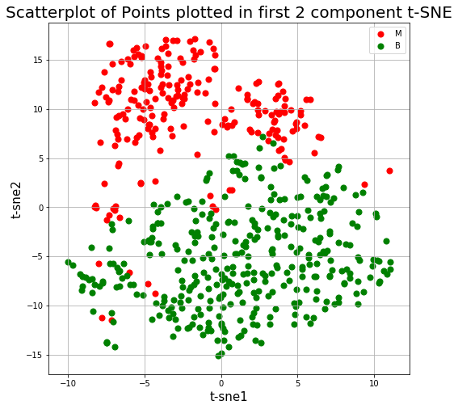

```python
#Visualización para el método t-SNE
fig = plt.figure(figsize = (8,8))
ax = fig.add_subplot(1,1,1)
ax.set_xlabel('t-sne1', fontsize = 15)
ax.set_ylabel('t-sne2', fontsize = 15)
ax.set_title('Scatterplot of Points plotted in first 2 component t-SNE', fontsize = 20)
targets = ['M', 'B']
colors = ['r', 'g']
for target, color in zip(targets,colors):
    indicesToKeep = df_tsne_with_target['diagnosis'] == target
    ax.scatter(df_tsne_with_target.loc[indicesToKeep, 't-sne1']
               , df_tsne_with_target.loc[indicesToKeep, 't-sne2']
               , c = color
               , s = 50)
ax.legend(targets)
ax.grid()
```

**Análisis:**  
- Qué método de reducción de dimensionalidad ha resultado más efectivo para visualizar las dos clases de diagnóstico de forma separada?

A mi parecer, para este caso en particular de dos atributos y estos datos parece que el algoritmo de PCA separa los diferentes datos de manera más clara que el t-SNE. No obstante, puede ser que para otro tipo de problemas u otro número de atributos funcione mejor el t-SNE.

- BONUS: cuándo es más apropriado usar PCA o t-SNE?

El **PCA** es **una técinca de reducción de la dimensión de manera lineal que se centra en maximizar la varianza y conservar grandes distancia entre pares**. El problema de esta visualización es que puede presentar problemas para estrcturas de datos que no siguen una estructura lineal. Sin embargo, el **t-SNE** es **una técnica no lineal de manera que se amolda a la figura que dibujan los datos**. Además,**se centra en conservar únicamente las pequeñas distancias entre pares o similaridades locales**. Otra diferencia es PCA es un algoritmo determinístico mientras que el t-SNE no lo es.

Depende de la tipología del problema puede ser más apropiado utilizar uno u otro. Mientras que el **PCA está enfocado a problemas lineales, el t-SNE está enfocado a problemas no lineales**. Además, t-SNE es un algoritmo probabilístico que utiliza dos distribuciones distintas para encontrar las similaridades mientras que el PCA es un algoritmo determinístico.

Para nuestro problema en concreto, tras ver la representación de los datos con ambos algoritmos, **se puede observar que para estos datos en particular interesa aplicar el algoritmo del PCA para que aplique un algoritmo determinístico lineal para la separación de variables.**

# 4. Aplicación de CART (3 puntos)

En este último ejercicio se trata de aplicar un método de aprendizaje supervisado, concretamente los árboles de decisión, para predecir el diagnóstico de cáncer de mama (tumor benigno o maligno) y evaluar la precisión obtenida con el modelo, usando:

- El conjunto de datos original con todos los atributos
- El conjunto de datos reducido a sólo 2 atributos con el método PCA

**Implementación:** Entrenad dos modelos usando árboles de decisión (con una profundidad máxima limitada a 3 niveles para mantener el modelo simple): uno usando el conjunto de datos original y el otro usando el conjunto de datos reducido con PCA.  
Calculad la precisión de las predicciones obtenidas por cada uno de los modelos (accuracy) así como la matriz de confusión asociada.

Sugerencia: es necesario que generéis un conjunto de datos de entrenamiento para calibrar el modelo, y otro conjunto de test para evaluar la bondad de cada uno de los modelos creados. Podéis usar los módulos 'train_test_split', 'DecisionTreeClassifier' y las funciones dentro del módulo 'metrics' de sckit-learn.

```python
from sklearn.model_selection import KFold

def CART_decisionTreeClassifier_Train(x_train, y_train, x_test, y_test):

    # Juntamos el train dentro de una matriz para poder realizar el split del
    # k-fold cross validation de una manera más sencilla
    _data = x_train
    _data['diagnosis'] = y_train
    n_samples, n_features = _data.shape
    print("Numero de filas: ", n_samples, "y el numero de columnas", n_features)

    #**********************************************************************************
    #************************************TRAIN*****************************************
    #**********************************************************************************
    n_samples, n_features = _data.shape
    print("Numero de filas: ", n_samples, "y el numero de columnas", n_features)
    cv = KFold(n_splits=5) # Asignamos el numero de las k-fold que queremos realizar
    accuracies = list()
    depth = 3 # Profundidad 3 en nuestro algoritmo de árboles de decisión

    fold_accuracy = []
    clf_cart = DecisionTreeClassifier(class_weight=None, criterion='entropy', max_depth=depth,
            max_features=None, max_leaf_nodes=None, min_samples_leaf=5,
            min_samples_split=2, min_weight_fraction_leaf=0.0,
            presort=False, random_state=100, splitter='best')

    # Dentro de la división que ha realizado KFold, dividimos en conjunto de entrenamiento
    # y conjunto de validación
    for train_fold, valid_fold in cv.split(_data):
        f_train = _data.iloc[train_fold]
        f_valid = _data.iloc[valid_fold]

        model = clf_cart.fit(X = f_train.drop(['diagnosis'], axis=1), y=f_train['diagnosis'])
        valid_acc = model.score(X = f_valid.drop(['diagnosis'], axis=1), y=f_valid['diagnosis']) # calculamos la precision con el segmento de validacion
        fold_accuracy.append(valid_acc)

    avg = sum(fold_accuracy)/len(fold_accuracy)
    print("El accuracy en train es de:", avg)

    return model;
```

Para este ejercicio se ha optado por dividir el conjunto de datos en dos subconjuntos:

- **Conjunto de entrenamiento (*train*)**, que contendrá el 70% de los datos proporcionados.
- **Conjunto de validación (*test*)**, que contendrá el 30% restante.

A continuación, para el conjunto de entrenamiento aplicaremos una metodología de aprendizaje basada en **árboles de decisión con el algoritmo CART** y aplicaremos un **k-fold cross validation** para poder garantizar que son independientes de la partición que se realiza inicialmente entre datos de entrenamiento y prueba. Para este problema en particular hemos parametrizado con un *k=5.*

**Empezaremos con el conjunto de datos original con todos los atributos.**

```python
x_1 = x
y_1 = y.map({"M":0, "B":1})

# dividimos en dos: 70% para train y 30% para test
x_train, x_test, y_train, y_test = train_test_split(x_1, y_1, test_size=0.3, random_state=42)

#_Llamamos a la función de clasificación que aplicará k-fold cross validation con k=5
# y nos devolverá un modelo de entrenamiento
clf_cart = CART_decisionTreeClassifier_Train(x_train, y_train, x_test, y_test)
```

```
Numero de filas:  398 y el numero de columnas 31
Numero de filas:  398 y el numero de columnas 31
El accuracy en train es de: 0.9396835443037975
```

Ahora bien, una vez entrenado tenemos un modelo que nos permitirá predecir para nuevos valores su etiqueta de clase. Una vez predicho compararemos la clase predicha con la clase real para obtener su **precisión (accuracy)** y mostrar la **matríz de confusión** que nos permitirá conocer los **Verdaderos Positivos, Verdaderos Negativos, Falsos Positivos y Falsos Negativos**.

```
El accuracy en test es: 94.15204678362574
```

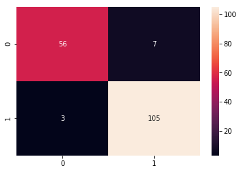

```python
#**********************************************************************************
#************************************Test******************************************
#**********************************************************************************

# Probamos la predicción del modelo de entrenamiento previamente creado
y_pred = clf_cart.predict(x_test)

print ("El accuracy en test es:", accuracy_score(y_test,y_pred)*100)
cm = confusion_matrix(y_test,y_pred)
sns.heatmap(cm,annot=True,fmt="d")
plt.show()
```

**Continuaremos con el conjunto de datos reducido a sólo 2 atributos con el método PCA.**

```
Numero de filas:  398 y el numero de columnas 3
Numero de filas:  398 y el numero de columnas 3
El accuracy en train es de: 0.9296518987341772
(171,)
El accuracy en test es: 95.90643274853801
```

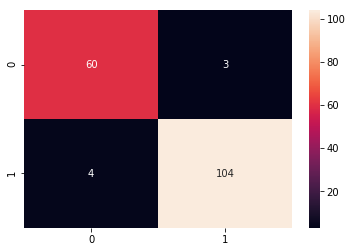

```python
y_2 = finalDf['diagnosis'].map({"M":0, "B":1})
x_2 = finalDf.drop(['diagnosis'], axis = 1)

x_train_pca, x_test_pca, y_train_pca, y_test_pca = train_test_split(x_2, y_2, test_size=0.3, random_state=42)


clf_cart_PCA = CART_decisionTreeClassifier_Train(x_train_pca,y_train_pca, x_test_pca, y_test_pca)

y_pred_pca = clf_cart_PCA.predict(x_test_pca)
print(y_pred_pca.shape)

print ("El accuracy en test es:", accuracy_score(y_test_pca,y_pred_pca)*100)

cm = confusion_matrix(y_test_pca,y_pred_pca)
sns.heatmap(cm,annot=True,fmt="d")
plt.show()
```

**Visualizamos matríz de confusión.**

**Análisis:**  
- Con qué tipo de datos (originales o reducidos) has obtenido una precisión (accuracy) mayor?

El modelo que ha aprendido a partir de **los dos atributos proporcionados por el PCA** ha obtenido un accuracy de **95,9**, algo mayor que el modelo que aprendió a partir de **todos los atributos** ha obtenido un accuracy de **94,1**.

- Si el usuario del modelo de predicción, un hospital por ejemplo, quisese usar el modelo con el menor número de tumores malignos erroneamente clasificados como benignos, cuál de los dos modelos tendría que usar? Porqué?

Para este caso debería escoger **el modelo que entrenó con los atributos proporcionados por PCA** ya que el número de **falsos negativos** es 3 frente a los 7 que obtuvo el otro modelo.

Este modelo tiene pinta de ser un model conservador que intenta minimizar los **falsos positivos** (solo 3) frente a los **falsos positivos** (son 4) o lo que es lo mismo prefiere catalogar un tumor benigno como maligno que clasificar un tumor maligno como benigno.

- Y si el hospital quisese usar el modelo con el menor número de tumores benignos erroneamente clasificados como malignos, cuál de los dos modelos usaría? Porqué?

En este caso le interesaría coger el modelo que aprendió a partir de todos los atributos ya que tiene 3 **falsos positivos** frente a los 4 **falsos positivos** que tiene el modelo del PCA.